# Election map of Stockholm 2018

Kristofer Svensson

Trying to make a pictore of the election result from the general election 2018.

SF (Simple features), is a library for GIS purposes which can handle most of the types of GIS-files that is supported in software as QGIS and ArcGIS.

As both the election districts data and the Stockholm map is in ESRI shape file format, SF is an exellent choice for working with the files.

dplyr is a standard library for working with tidy data files and comes with the Tidyverse suite of libraries, as is also the case with ggplot2 which is the de fact standard library for making visualisations in R.

```
  LAN       LAN_NAMN RVK          RVK_NAMN LND                  LND_NAMN  LVK            LVK_NAMN  KOM
1  01 Stockholms län  01 Stockholms kommun  01 Stockholms läns landsting 0101 1 Södermalm-Enskede 0180
2  01 Stockholms län  01 Stockholms kommun  01 Stockholms läns landsting 0101 1 Södermalm-Enskede 0180
3  01 Stockholms län  01 Stockholms kommun  01 Stockholms läns landsting 0101 1 Södermalm-Enskede 0180
4  01 Stockholms län  01 Stockholms kommun  01 Stockholms läns landsting 0101 1 Södermalm-Enskede 0180
5  01 Stockholms län  01 Stockholms kommun  01 Stockholms läns landsting 0101 1 Södermalm-Enskede 0180
6  01 Stockholms län  01 Stockholms kommun  01 Stockholms läns landsting 0101 1 Södermalm-Enskede 0180
   NAMN_KOM    KVK            KVK_NAMN       VD                    VD_NAMN                       geometry
1 Stockholm 018001 1 Södermalm-Enskede 01801301 Maria 1 Ivar Lo:s park mfl MULTIPOLYGON (((153495.8 65...
2 Stockholm 018001 1 Södermalm-Enskede 01801302      Maria 2 Mariaberget V MULTIPOLYGON (((153369.8 65...
3 Stockholm 018001 1 Södermalm-Enskede 01801303      Maria 3 Mariatorget V MULTIPOLYGON (((153449.7 65...
4 Stockholm 018001 1 Södermalm-Enskede 01801304        Maria 4 Bergsgruvan MULTIPOLYGON (((153262.1 65...
5 Stockholm 018001 1 Södermalm-Enskede 01801305      Maria 5 Mariatorget S MULTIPOLYGON (((153760.1 65...
6 Stockholm 018001 1 Södermalm-Enskede 01801306      Maria 6 Mariatorget C MULTIPOLYGON (((153843.1 65...
```

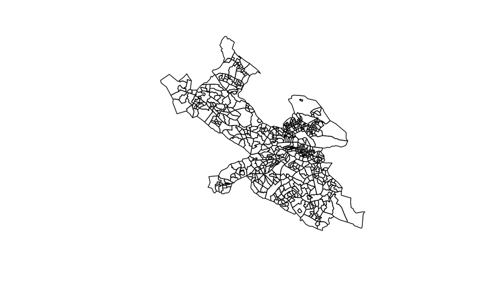

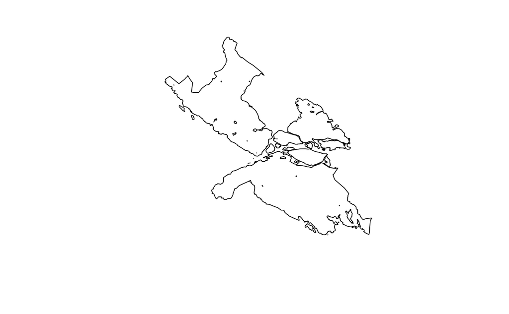

Mycket vatten. Slå ihop med valdistriktkarta för att få bort vatten.

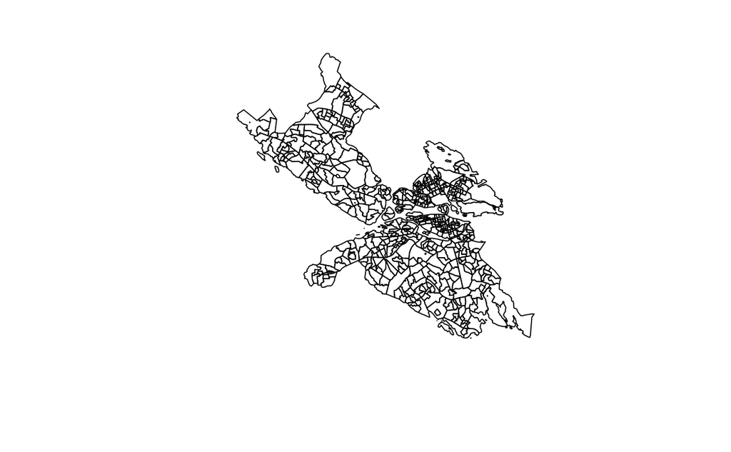

```
value for "which" not specified, defaulting to c("rows", "cols")
* `` -> ...11
```

| valkretskod | valkretsnamn | valdistriktskod | valdistriktsnamn | antal_rostberattigade | antal_rostande | andel_rostande | antal_ogiltiga_valsedlar | varav_blanka_valsedlar | antal_giltiga_valsedlar | m | c | l | kd | mp | s | v | sd | ovr |
| --- | --- | --- | --- | --- | --- | --- | --- | --- | --- | --- | --- | --- | --- | --- | --- | --- | --- | --- |
| 02 | Stockholms län | 01140101 | Övra Runby | 1355 | 1110 | 81.91882 | 13 | 11 | 1097 | 201 | 90 | 82 | 59 | 61 | 286 | 113 | 186 | 19 |
| 02 | Stockholms län | 01140102 | Mälaren | 1073 | 914 | 85.18173 | 9 | 9 | 905 | 201 | 60 | 70 | 66 | 45 | 237 | 61 | 153 | 12 |
| 02 | Stockholms län | 01140120 | Edssjön | 830 | 678 | 81.68675 | 4 | 3 | 674 | 158 | 38 | 39 | 52 | 36 | 194 | 57 | 94 | 6 |
| 02 | Stockholms län | 01140121 | Nedra Runby | 1104 | 929 | 84.14855 | 9 | 8 | 920 | 176 | 60 | 53 | 53 | 56 | 260 | 80 | 162 | 20 |
| 02 | Stockholms län | 01140126 | Prästgårdsmarken | 890 | 702 | 78.87640 | 8 | 7 | 694 | 90 | 45 | 21 | 26 | 42 | 217 | 77 | 160 | 16 |
| 02 | Stockholms län | 01140203 | Folkparken | 1102 | 929 | 84.30127 | 3 | 2 | 926 | 199 | 56 | 52 | 66 | 44 | 245 | 76 | 177 | 11 |

```r
unique(election_data$valkretsnamn)
```

```
 [1] "Stockholms län"               "Stockholms kommun"            "Uppsala län"
 [4] "Södermanlands län"            "Östergötlands län"            "Jönköpings län"
 [7] "Kronobergs län"               "Kalmar län"                   "Gotlands län"
[10] "Blekinge län"                 "Skåne läns västra"            "Skåne läns södra"
[13] "Skåne läns norra och östra"   "Malmö kommun"                 "Hallands län"
[16] "Västra Götalands läns västra" "Västra Götalands läns norra"  "Västra Götalands läns södra"
[19] "Västra Götalands läns östra"  "Göteborgs kommun"             "Värmlands län"
[22] "Örebro län"                   "Västmanlands län"             "Dalarnas län"
[25] "Gävleborgs län"               "Västernorrlands län"          "Jämtlands län"
[28] "Västerbottens län"            "Norrbottens län"
```

We can see that we are lucky: Stockholms kommun is a separate factor, so we can filter out the districts we are interested in by just filter for the ‘valkrets’ variable.

| valkretskod | valkretsnamn | valdistriktskod | valdistriktsnamn | antal_rostberattigade | antal_rostande | andel_rostande | antal_ogiltiga_valsedlar | varav_blanka_valsedlar | antal_giltiga_valsedlar | parti | resultat |
| --- | --- | --- | --- | --- | --- | --- | --- | --- | --- | --- | --- |
| 01 | Stockholms kommun | 01800101 | Domkyrko 1 Gamla stan inre | 1436 | 1127 | 78.48189 | 4 | 2 | 1123 | m | 241 |
| 01 | Stockholms kommun | 01800101 | Domkyrko 1 Gamla stan inre | 1436 | 1127 | 78.48189 | 4 | 2 | 1123 | c | 103 |
| 01 | Stockholms kommun | 01800101 | Domkyrko 1 Gamla stan inre | 1436 | 1127 | 78.48189 | 4 | 2 | 1123 | l | 91 |
| 01 | Stockholms kommun | 01800101 | Domkyrko 1 Gamla stan inre | 1436 | 1127 | 78.48189 | 4 | 2 | 1123 | kd | 98 |
| 01 | Stockholms kommun | 01800101 | Domkyrko 1 Gamla stan inre | 1436 | 1127 | 78.48189 | 4 | 2 | 1123 | mp | 102 |
| 01 | Stockholms kommun | 01800101 | Domkyrko 1 Gamla stan inre | 1436 | 1127 | 78.48189 | 4 | 2 | 1123 | s | 214 |

```r
election_map_result_national <- inner_join(election_district_no_water, election_data, by = c("VD_NAMN" = "valdistriktsnamn"))

head(election_map_result_national)
```

```
Simple feature collection with 6 features and 25 fields
Geometry type: POLYGON
Dimension:     XY
Bounding box:  xmin: 153209.4 ymin: 6578162 xmax: 153977.1 ymax: 6578467
Projected CRS: SWEREF99 18 00
  LAN       LAN_NAMN RVK          RVK_NAMN LND                  LND_NAMN  LVK            LVK_NAMN  KOM
1  01 Stockholms län  01 Stockholms kommun  01 Stockholms läns landsting 0101 1 Södermalm-Enskede 0180
2  01 Stockholms län  01 Stockholms kommun  01 Stockholms läns landsting 0101 1 Södermalm-Enskede 0180
3  01 Stockholms län  01 Stockholms kommun  01 Stockholms läns landsting 0101 1 Södermalm-Enskede 0180
4  01 Stockholms län  01 Stockholms kommun  01 Stockholms läns landsting 0101 1 Södermalm-Enskede 0180
5  01 Stockholms län  01 Stockholms kommun  01 Stockholms läns landsting 0101 1 Södermalm-Enskede 0180
6  01 Stockholms län  01 Stockholms kommun  01 Stockholms läns landsting 0101 1 Södermalm-Enskede 0180
   NAMN_KOM    KVK            KVK_NAMN       VD                    VD_NAMN valkretskod      valkretsnamn
1 Stockholm 018001 1 Södermalm-Enskede 01801301 Maria 1 Ivar Lo:s park mfl          01 Stockholms kommun
2 Stockholm 018001 1 Södermalm-Enskede 01801301 Maria 1 Ivar Lo:s park mfl          01 Stockholms kommun
```

[output cut: 18 more lines]

```r
election_data_top_national <- election_map_result_national %>%
  group_by(VD_NAMN) %>%
  slice_max(n = 1, order_by = resultat, with_ties = FALSE)

head(election_data_top_national)
```

```
Simple feature collection with 6 features and 25 fields
Geometry type: POLYGON
Dimension:     XY
Bounding box:  xmin: 152587.2 ymin: 6579820 xmax: 153693.8 ymax: 6580784
Projected CRS: SWEREF99 18 00
```

| LAN | LAN_NAMN | RVK | RVK_NAMN | LND | LND_NAMN | LVK | LVK_NAMN | KOM | NAMN_KOM | KVK | KVK_NAMN | VD | VD_NAMN | valkretskod | valkretsnamn | valdistriktskod | antal_rostberattigade | antal_rostande | andel_rostande | antal_ogiltiga_valsedlar | varav_blanka_valsedlar | antal_giltiga_valsedlar | parti | resultat | geometry |
| --- | --- | --- | --- | --- | --- | --- | --- | --- | --- | --- | --- | --- | --- | --- | --- | --- | --- | --- | --- | --- | --- | --- | --- | --- | --- |
| 01 | Stockholms län | 01 | Stockholms kommun | 01 | Stockholms läns landsting | 0103 | 3 Norrmalm-Östermalm-Gamla Stan | 0180 | Stockholm | 018003 | 3 Norrmalm-Östermalm-Gamla Stan | 01800501 | Adolf Fredrik 1 Tegnérlunden V | 01 | Stockholms kommun | 01800501 | 1291 | 1046 | 81.02246 | 4 | 4 | 1042 | m | 381 |  |
| 01 | Stockholms län | 01 | Stockholms kommun | 01 | Stockholms läns landsting | 0103 | 3 Norrmalm-Östermalm-Gamla Stan | 0180 | Stockholm | 018003 | 3 Norrmalm-Östermalm-Gamla Stan | 01800502 | Adolf Fredrik 2 Rådmansgatan mfl | 01 | Stockholms kommun | 01800502 | 1309 | 1144 | 87.39496 | 7 | 3 | 1137 | m | 364 |  |
| 01 | Stockholms län | 01 | Stockholms kommun | 01 | Stockholms läns landsting | 0103 | 3 Norrmalm-Östermalm-Gamla Stan | 0180 | Stockholm | 018003 | 3 Norrmalm-Östermalm-Gamla Stan | 01800503 | Adolf Fredrik 3 Adolf Fredriks SÖ | 01 | Stockholms kommun | 01800503 | 1296 | 1086 | 83.79630 | 3 | 3 | 1083 | m | 336 |  |
| 01 | Stockholms län | 01 | Stockholms kommun | 01 | Stockholms läns landsting | 0103 | 3 Norrmalm-Östermalm-Gamla Stan | 0180 | Stockholm | 018003 | 3 Norrmalm-Östermalm-Gamla Stan | 01800504 | Adolf Fredrik 4 Norra Bantorget | 01 | Stockholms kommun | 01800504 | 1152 | 987 | 85.67708 | 4 | 4 | 983 | m | 303 |  |
| 01 | Stockholms län | 01 | Stockholms kommun | 01 | Stockholms läns landsting | 0103 | 3 Norrmalm-Östermalm-Gamla Stan | 0180 | Stockholm | 018003 | 3 Norrmalm-Östermalm-Gamla Stan | 01800505 | Adolf Fredrik 5 Spökparken | 01 | Stockholms kommun | 01800505 | 976 | 846 | 86.68033 | 2 | 2 | 844 | m | 318 |  |
| 01 | Stockholms län | 01 | Stockholms kommun | 01 | Stockholms läns landsting | 0103 | 3 Norrmalm-Östermalm-Gamla Stan | 0180 | Stockholm | 018003 | 3 Norrmalm-Östermalm-Gamla Stan | 01800506 | Adolf Fredrik 6 Tegnérlunden södra | 01 | Stockholms kommun | 01800506 | 1168 | 996 | 85.27397 | 5 | 4 | 991 | m | 304 |  |

```r
election_data_top_national %>%
  group_by(parti) %>%
  summarise(count = n())
```

| parti | count | geometry |
| --- | --- | --- |
| m | 222 |  |
| s | 335 |  |
| v | 16 |  |

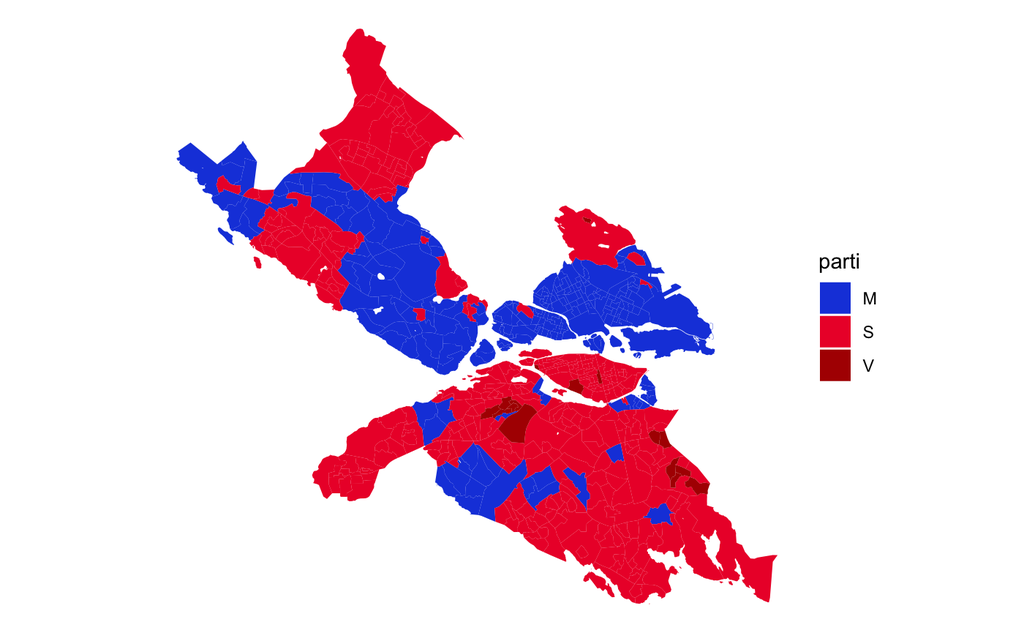

```r
election_data_top_national %>%
  ggplot(
    aes(
      fill = parti
    )
  ) +
  geom_sf(colour = NA) +
  theme_void() +
  scale_fill_manual(
    breaks = c("m", "s", "v"), labels = c("M", "S", "V"), values = c("#1b49dd", "#ed1b34", "#b00000")
  )
```

The map above shows which party was the biggest in each election district. However, it does not show which block of parties was the bigger. To show this we divide the parties inte the two major groups in the Swedish parliament:

```r
election_map_result_national %<>%
  mutate(
    block_h_v = ifelse(parti %in% c("m", "kd", "l", "sd"), "M-KD-L-SD", "S-C-Mp-V")
  )
```

Now we plot this:

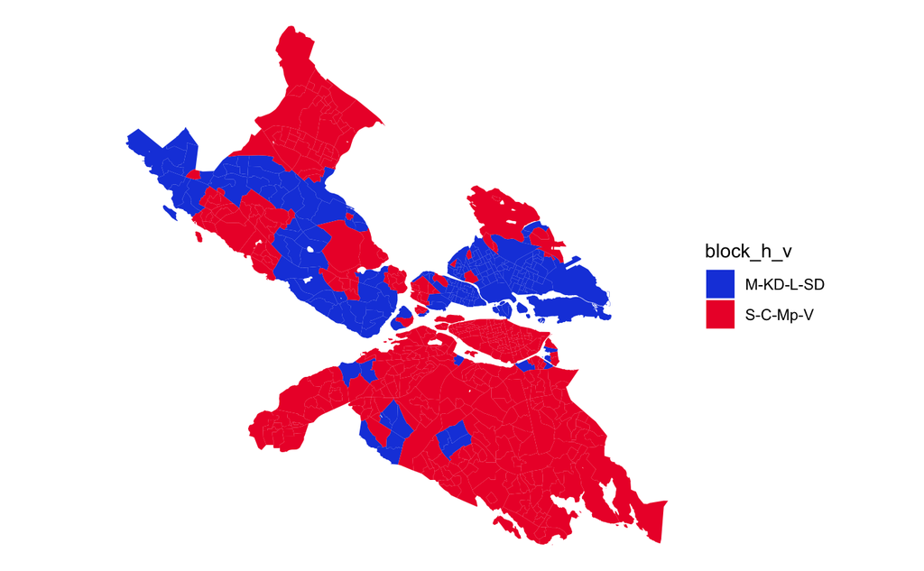

```r
election_map_result_national %>%
  group_by(VD_NAMN, block_h_v) %>%
  summarise(votes = sum(resultat)) %>%
  group_by(VD_NAMN) %>%
  slice_max(n = 1, order_by = votes, with_ties = FALSE) %>%
  ggplot(
    aes(
      fill = block_h_v
    )
  ) +
  geom_sf(colour = NA) +
  theme_void() +
  scale_fill_manual(
    breaks = c("M-KD-L-SD", "S-C-Mp-V"), values = c("#1b49dd", "#ed1b34")
  )
```

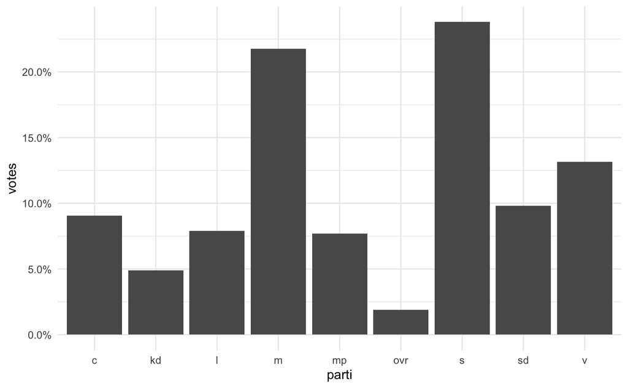

```r
election_map_result_national %>%
  group_by(parti) %>%
  summarise(votes = sum(resultat)/sum(election_map_result_national$resultat)) %>%
  ggplot(
    aes(x = parti, y = votes)
  ) +
  geom_col() +
  theme_minimal() +
  scale_y_continuous(labels = scales::label_percent())
```

It’s hard to visualise this. Dot density map can be the way to go!

```r
st_sample(election_map_result_national, 10)
```

```
Geometry set for 10 features
Geometry type: POINT
Dimension:     XY
Bounding box:  xmin: 143257.4 ymin: 6575390 xmax: 156855.1 ymax: 6588502
Projected CRS: SWEREF99 18 00
First 5 geometries:
```

```
POINT (143257.4 6586700)
POINT (143764.6 6585609)
POINT (144437.4 6581038)
POINT (143361.2 6586047)
POINT (146631.5 6576220)
```